# Tiempo hasta el inicio del estudio

Autor/a

Mario Camacho

Fecha de publicación

08 marzo 2025

**Stakeholder:** Jose L Merino Rivas **Centro:** Hospital del Henares  
**Fecha última modificación:** 23 abril 2026

Media de ferritina, ferritina vs basal y ferritina vs t-1 por mes.

```
## # A tibble: 2 × 8
##   Aleatorización `0 meses` `2 meses` `4 meses` `6 meses` `8 meses` `10 meses`
##   <fct>              <dbl>     <dbl>     <dbl>     <dbl>     <dbl>      <dbl>
## 1 Venofer             429.      432.      457.      492.      444.       496.
## 2 Ferinject           338.      342.      410.      333.      397.       381.
## # ℹ 1 more variable: `12 meses` <dbl>
## # A tibble: 2 × 8
##   Aleatorización `0 meses` `2 meses` `4 meses` `6 meses` `8 meses` `10 meses`
##   <fct>              <dbl>     <dbl>     <dbl>     <dbl>     <dbl>      <dbl>
## 1 Venofer                0     -9.38      28.5      54.2      7.62       43.8
## 2 Ferinject              0     -5.73      59.9     -22.1     42.0        21.9
## # ℹ 1 more variable: `12 meses` <dbl>
## # A tibble: 2 × 8
##   Aleatorización `0 meses` `2 meses` `4 meses` `6 meses` `8 meses` `10 meses`
##   <fct>              <dbl>     <dbl>     <dbl>     <dbl>     <dbl>      <dbl>
## 1 Venofer                0     -9.38      39.2      12.8     -32.4       16.8
## 2 Ferinject              0     -5.73      57.7     -76.9      74.4      -18.7
## # ℹ 1 more variable: `12 meses` <dbl>
```

Repetimos el cálculo media de ferritina, ferritina vs basal y ferritina vs t-1 por mes aplicando logaritmos.

```
## # A tibble: 2 × 8
##   Aleatorización `0 meses` `2 meses` `4 meses` `6 meses` `8 meses` `10 meses`
##   <fct>              <dbl>     <dbl>     <dbl>     <dbl>     <dbl>      <dbl>
## 1 Venofer             5.87      5.94      5.98      6.08      5.90       6.09
## 2 Ferinject           5.57      5.60      5.83      5.55      5.59       5.69
## # ℹ 1 more variable: `12 meses` <dbl>
## # A tibble: 2 × 8
##   Aleatorización `0 meses` `2 meses` `4 meses` `6 meses` `8 meses` `10 meses`
##   <fct>              <dbl>     <dbl>     <dbl>     <dbl>     <dbl>      <dbl>
## 1 Venofer                0  -0.00389     0.104    0.183     0.0198     0.122
## 2 Ferinject              0  -0.0100      0.218   -0.0787   -0.0255     0.0655
## # ℹ 1 more variable: `12 meses` <dbl>
## # A tibble: 2 × 8
##   Aleatorización `0 meses` `2 meses` `4 meses` `6 meses` `8 meses` `10 meses`
##   <fct>              <dbl>     <dbl>     <dbl>     <dbl>     <dbl>      <dbl>
## 1 Venofer                0  -0.00389     0.119    0.0401   -0.144      0.0397
## 2 Ferinject              0  -0.0100      0.205   -0.282     0.0892     0.0749
## # ℹ 1 more variable: `12 meses` <dbl>
```

Media de hemoglobina, hemoglobina vs basal y hemoglobina vs t-1 por mes.

```
## # A tibble: 2 × 8
##   Aleatorización `0 meses` `2 meses` `4 meses` `6 meses` `8 meses` `10 meses`
##   <fct>              <dbl>     <dbl>     <dbl>     <dbl>     <dbl>      <dbl>
## 1 Venofer             12.0      11.8      12.2      11.8      11.7       12
## 2 Ferinject           12.3      12.6      12.4      11.9      11.6       11.8
## # ℹ 1 more variable: `12 meses` <dbl>
## # A tibble: 2 × 8
##   Aleatorización `0 meses` `2 meses` `4 meses` `6 meses` `8 meses` `10 meses`
##   <fct>              <dbl>     <dbl>     <dbl>     <dbl>     <dbl>      <dbl>
## 1 Venofer                0    -0.255     0.197    -0.296    -0.344     -0.174
## 2 Ferinject              0     0.216     0.143    -0.397    -0.704     -0.392
## # ℹ 1 more variable: `12 meses` <dbl>
## # A tibble: 2 × 8
##   Aleatorización `0 meses` `2 meses` `4 meses` `6 meses` `8 meses` `10 meses`
##   <fct>              <dbl>     <dbl>     <dbl>     <dbl>     <dbl>      <dbl>
## 1 Venofer                0    -0.255     0.466    -0.388  -0.00400      0.296
## 2 Ferinject              0     0.216    -0.131    -0.54   -0.300        0.342
## # ℹ 1 more variable: `12 meses` <dbl>
```

Repetimos el cálculo media de hemoglobina, hemoglobina vs basal y hemoglobina vs t-1 por mes aplicando logaritmos.

```
## # A tibble: 2 × 8
##   Aleatorización `0 meses` `2 meses` `4 meses` `6 meses` `8 meses` `10 meses`
##   <fct>              <dbl>     <dbl>     <dbl>     <dbl>     <dbl>      <dbl>
## 1 Venofer             2.48      2.46      2.49      2.46      2.46       2.48
## 2 Ferinject           2.50      2.52      2.51      2.47      2.44       2.46
## # ℹ 1 more variable: `12 meses` <dbl>
## # A tibble: 2 × 8
##   Aleatorización `0 meses` `2 meses` `4 meses` `6 meses` `8 meses` `10 meses`
##   <fct>              <dbl>     <dbl>     <dbl>     <dbl>     <dbl>      <dbl>
## 1 Venofer                0   -0.0226    0.0166   -0.0243   -0.0297    -0.0164
## 2 Ferinject              0    0.0200    0.0130   -0.0315   -0.0612    -0.0361
## # ℹ 1 more variable: `12 meses` <dbl>
## # A tibble: 2 × 8
##   Aleatorización `0 meses` `2 meses` `4 meses` `6 meses` `8 meses` `10 meses`
##   <fct>              <dbl>     <dbl>     <dbl>     <dbl>     <dbl>      <dbl>
## 1 Venofer                0   -0.0226    0.0405   -0.0320  -0.00178     0.0244
## 2 Ferinject              0    0.0200   -0.0117   -0.0445  -0.0293      0.0283
## # ℹ 1 more variable: `12 meses` <dbl>
```

## Tiempo hasta el inicio del estudio

**Implicación clínica**

Tiempo hasta inicio del estudio (meses) según grupo de aleatorización

| Aleatorización | n | media | sd | mediana | Q1 | Q3 |
| --- | --- | --- | --- | --- | --- | --- |
| Venofer | 30 | 54.4 | 45.7 | 39.5 | 17.5 | 79.0 |
| Ferinject | 34 | 40.5 | 34.4 | 31.0 | 18.5 | 58.5 |

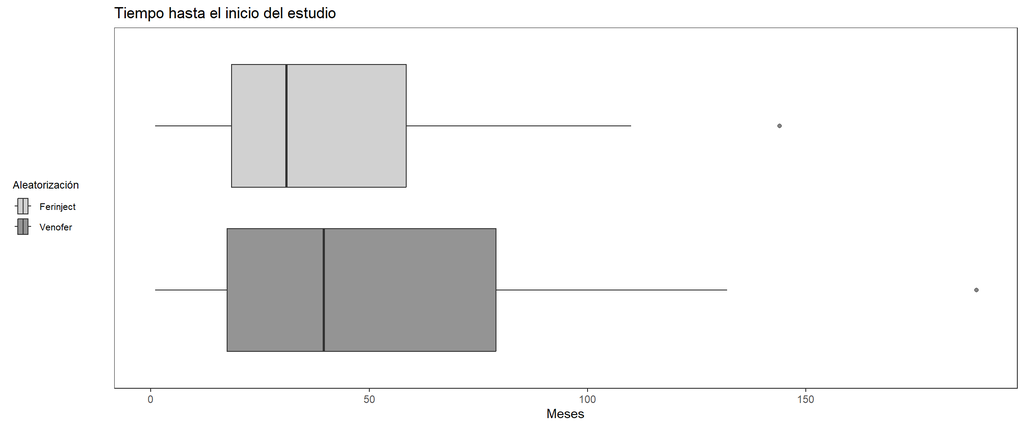

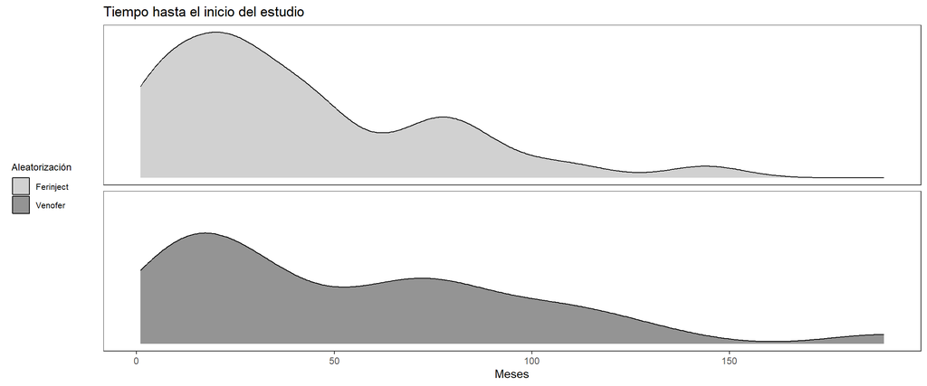

**Implicación clínica**

```
    Wilcoxon rank sum test with continuity correction

data:  Tiempo hasta inicio estudio (meses) by Aleatorización
W = 580, p-value = 0.3496
alternative hypothesis: true location shift is not equal to 0
```

Categorizamos el tiempo hasta el inicio del estudio en cinco categorías: < 1 año, 1-2 años, 2-3 años, 3-4 años, > 4 años.

## Distribución de la ferritina en el Control Basal según el tiempo hasta el inicio del estudio

**Implicación clínica**

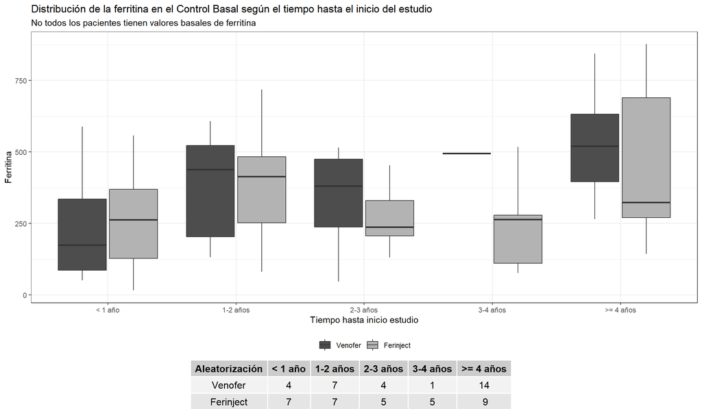

Nota: el paciente con id 3 (rama Ferinject) no tiene medición de la ferritina en el Control Basal.

Distribución de la ferritina basal según el tiempo hasta el estudio

| Tiempo hasta el inicio del estudio | Aleatorización | n | Pacientes con ferritina basal | media | sd | mediana | Q1 | Q3 |
| --- | --- | --- | --- | --- | --- | --- | --- | --- |
| < 1 año | Venofer | 4 | 4 | 247.2 | 243.3 | 174.5 | 86.2 | 335.5 |
| < 1 año | Ferinject | 7 | 7 | 261.4 | 186.4 | 263 | 127.5 | 369 |
| 1-2 años | Venofer | 7 | 7 | 375.9 | 191.9 | 439 | 203 | 523 |
| 1-2 años | Ferinject | 7 | 7 | 383.6 | 220.3 | 414 | 252.5 | 483.5 |
| 2-3 años | Venofer | 4 | 4 | 331.2 | 210.2 | 381.5 | 237.5 | 475.2 |
| 2-3 años | Ferinject | 5 | 5 | 271.8 | 123.9 | 238 | 207 | 330 |
| 3-4 años | Venofer | 1 | 1 | 495 | NA | 495 | 495 | 495 |
| 3-4 años | Ferinject | 5 | 5 | 249.6 | 174.3 | 264 | 111 | 279 |
| >= 4 años | Venofer | 14 | 14 | 529.8 | 172.5 | 520.5 | 396 | 632.2 |
| >= 4 años | Ferinject | 10 | 9 | 447 | 257.2 | 324 | 271 | 690 |

## Distribución de la hemogoblina en el Control Basal según el tiempo hasta el inicio del estudio

**Implicación clínica**

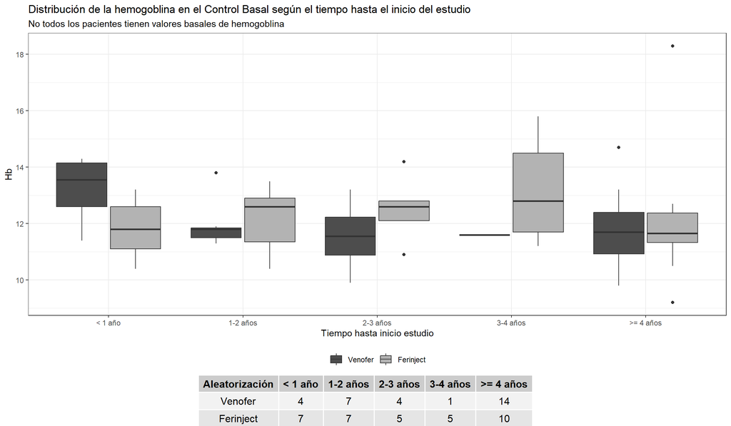

Distribución de la hemogoblina basal según el tiempo hasta el estudio

| Tiempo hasta el inicio del estudio | Aleatorización | n | Pacientes con hemoglobina basal | media | sd | mediana | Q1 | Q3 |
| --- | --- | --- | --- | --- | --- | --- | --- | --- |
| < 1 año | Venofer | 4 | 4 | 13.2 | 1.3 | 13.6 | 12.6 | 14.1 |
| < 1 año | Ferinject | 7 | 7 | 11.8 | 1 | 11.8 | 11.1 | 12.6 |
| 1-2 años | Venofer | 7 | 7 | 11.9 | 0.8 | 11.8 | 11.5 | 11.9 |
| 1-2 años | Ferinject | 7 | 7 | 12.1 | 1.1 | 12.6 | 11.4 | 12.9 |
| 2-3 años | Venofer | 4 | 4 | 11.6 | 1.4 | 11.6 | 10.9 | 12.2 |
| 2-3 años | Ferinject | 5 | 5 | 12.5 | 1.2 | 12.6 | 12.1 | 12.8 |
| 3-4 años | Venofer | 1 | 1 | 11.6 | NA | 11.6 | 11.6 | 11.6 |
| 3-4 años | Ferinject | 5 | 5 | 13.2 | 1.9 | 12.8 | 11.7 | 14.5 |
| >= 4 años | Venofer | 14 | 14 | 11.8 | 1.3 | 11.7 | 10.9 | 12.4 |
| >= 4 años | Ferinject | 10 | 10 | 12.1 | 2.4 | 11.7 | 11.3 | 12.4 |